# Ford Go Bike Trip Data

## Preliminary Wrangling

> I am using the Bay Wheel(lyft) trip data for 12 months - Janury 2019-December 2019

```python
# import all packages and set plots to be embedded inline
import numpy as np
import pandas as pd
import matplotlib.pyplot as plt
import seaborn as sb
import glob
%matplotlib inline
import matplotlib.ticker as tick
from pandas.api.types import CategoricalDtype
```

> Download the data for last 12 months January 2019 to December 2019 from https://s3.amazonaws.com/baywheels-data/index.html

```python
# This block of code was executed once to collect all the data into a masterdata.csv

#Using glob to read more than one csv files and then concatinating to get one master data file
#appended_data = []
# for infile in glob.glob("*.csv"):
#    data = pd.read_csv(infile, low_memory=False)
# store DataFrame in list
#    appended_data.append(data)
#see pd.concat documentation for more info
#appended_data = pd.concat(appended_data, sort=True)
# write DataFrame to a csv file
#appended_data.to_csv('masterdata.csv')
```

```python
# Read the data from masterdata.csv into pandas dataframe
df = pd.read_csv('masterdata.csv',low_memory=False)
```

```python
# Check the columns and their data types
df.info()
```

```
<class 'pandas.core.frame.DataFrame'>
RangeIndex: 2506983 entries, 0 to 2506982
Data columns (total 16 columns):
Unnamed: 0                 int64
bike_id                    int64
bike_share_for_all_trip    object
duration_sec               int64
end_station_id             float64
end_station_latitude       float64
end_station_longitude      float64
end_station_name           object
end_time                   object
rental_access_method       object
start_station_id           float64
start_station_latitude     float64
start_station_longitude    float64
start_station_name         object
start_time                 object
user_type                  object
dtypes: float64(6), int64(3), object(7)
memory usage: 306.0+ MB
```

```python
# Check the shape of the dataframe
df.shape
```

```
(2506983, 16)
```

```python
# Get counts for different values of bike_share_for_all_trip
df.bike_share_for_all_trip.value_counts()
```

```
No     2203584
Yes     182561
Name: bike_share_for_all_trip, dtype: int64
```

```python
# Get counts for different values of rental_access_method
df.rental_access_method.value_counts()
```

```
app        108010
clipper     12828
Name: rental_access_method, dtype: int64
```

```python
# Get counts for different values of user_type
df.user_type.value_counts()
```

```
Subscriber    2021166
Customer       485817
Name: user_type, dtype: int64
```

```python
# Check for any duplicates
df.duplicated().sum()
```

```
0
```

## Data Cleaning

```python
# Make a copy of the dataframe before the cleaning process
fordtrips = df.copy()
```

```python
# Drop the columns which are not going to be used for analysis unnamed :0, end_station_name, start_station_name
fordtrips.drop(['Unnamed: 0','end_station_name','start_station_name'], axis = 1, inplace=True)
```

```python
# change the data types of the necessary columns as needed

# end_time & start_time needs to be datetime
fordtrips['end_time'] = pd.to_datetime(fordtrips['end_time'])
fordtrips['start_time'] = pd.to_datetime(fordtrips['start_time'])

# start_station_id & end_station_id needs to be changed from float 64 to str, because you don't need to do any numerical operation on these
fordtrips['start_station_id'] = fordtrips['start_station_id'].astype('str')
fordtrips['end_station_id'] = fordtrips['end_station_id'].astype('str')

# change bike_id from int64 to str, because you don't need to do any numerical operation on these
fordtrips['bike_id'] = fordtrips['bike_id'].astype('str')

# change user_typr to categorical column
fordtrips['user_type'] = fordtrips['user_type'].astype('category')
```

```python
# create a new column duration_minute to show the ride duration in munites instaed os seconds.
fordtrips['duration_minute'] = fordtrips['duration_sec']/60
```

```python
# create start_date in yyyy-mm-dd, start_hour in hh, start_month in mm and start_dayoftheweek d format

fordtrips['start_date'] = fordtrips.start_time.dt.strftime('%Y-%m-%d')
fordtrips['start_hourofday'] = fordtrips.start_time.dt.strftime('%H')
fordtrips['start_dayofweek'] = fordtrips.start_time.dt.strftime('%A')
fordtrips['start_month'] = fordtrips.start_time.dt.strftime('%B')
fordtrips['start_day'] = fordtrips.start_time.dt.strftime('%d')
```

```python
# change the datatype of start_dayofweek to ordered categorical dtype
weekday = ['Monday','Tuesday','Wednesday','Thursday','Friday','Saturday','Sunday']
weekday_category = pd.api.types.CategoricalDtype(categories=weekday, ordered=True)
fordtrips['start_dayofweek'] = fordtrips['start_dayofweek'].astype(weekday_category)
```

```python
# change the datatype of start_month to ordered categorical dtype
months = ['January','February','March','April','May','June','July','August','September','October','November','December']
months_category = pd.api.types.CategoricalDtype(categories=months, ordered=True)
fordtrips['start_month'] = fordtrips['start_month'].astype(months_category)
```

```python
fordtrips.head()
```

|  | bike_id | bike_share_for_all_trip | duration_sec | end_station_id | end_station_latitude | end_station_longitude | end_time | rental_access_method | start_station_id | start_station_latitude | start_station_longitude | start_time | user_type | duration_minute | start_date | start_hourofday | start_dayofweek | start_month | start_day |
| --- | --- | --- | --- | --- | --- | --- | --- | --- | --- | --- | --- | --- | --- | --- | --- | --- | --- | --- | --- |
| 0 | 12904 | No | 60863 | 465.0 | 37.776329 | -122.394438 | 2019-10-01 04:42:25.864 | NaN | 465.0 | 37.776329 | -122.394438 | 2019-09-30 11:48:02.710 | Customer | 1014.383333 | 2019-09-30 | 11 | Monday | September | 30 |
| 1 | 163 | No | 36019 | 443.0 | 37.320866 | -121.876279 | 2019-10-01 02:16:51.982 | NaN | 294.0 | 37.327581 | -121.884559 | 2019-09-30 16:16:32.353 | Customer | 600.316667 | 2019-09-30 | 16 | Monday | September | 30 |
| 2 | 10737 | No | 5615 | 4.0 | 37.785881 | -122.408915 | 2019-10-01 00:46:01.959 | NaN | 370.0 | 37.787327 | -122.413278 | 2019-09-30 23:12:25.998 | Customer | 93.583333 | 2019-09-30 | 23 | Monday | September | 30 |
| 3 | 10346 | No | 1482 | 460.0 | 37.769095 | -122.386333 | 2019-10-01 00:22:16.849 | NaN | 109.0 | 37.763316 | -122.421904 | 2019-09-30 23:57:34.663 | Customer | 24.700000 | 2019-09-30 | 23 | Monday | September | 30 |
| 4 | 1349 | No | 1272 | 127.0 | 37.756708 | -122.421025 | 2019-10-01 00:14:41.074 | NaN | 95.0 | 37.766219 | -122.431060 | 2019-09-30 23:53:28.653 | Subscriber | 21.200000 | 2019-09-30 | 23 | Monday | September | 30 |

```python
fordtrips.shape
```

```
(2506983, 19)
```

```python
fordtrips.info(null_counts=True)
```

```
<class 'pandas.core.frame.DataFrame'>
RangeIndex: 2506983 entries, 0 to 2506982
Data columns (total 19 columns):
bike_id                    2506983 non-null object
bike_share_for_all_trip    2386145 non-null object
duration_sec               2506983 non-null int64
end_station_id             2506983 non-null object
end_station_latitude       2506983 non-null float64
end_station_longitude      2506983 non-null float64
end_time                   2506983 non-null datetime64[ns]
rental_access_method       120838 non-null object
start_station_id           2506983 non-null object
start_station_latitude     2506983 non-null float64
start_station_longitude    2506983 non-null float64
start_time                 2506983 non-null datetime64[ns]
user_type                  2506983 non-null category
duration_minute            2506983 non-null float64
start_date                 2506983 non-null object
start_hourofday            2506983 non-null object
start_dayofweek            2506983 non-null category
start_month                2506983 non-null category
start_day                  2506983 non-null object
dtypes: category(3), datetime64[ns](2), float64(5), int64(1), object(8)
memory usage: 313.2+ MB
```

### Structure of the dataset

> There are 2506983 rows of trip data and 19 columns. The data provides three type of information for each trip.

> > Duration of the trip -- duration_sec, start_time, end_time

> > Station information -- start_station_id, start_station_latitude, start_station_longitude, end_station_id, end_station_latitude, end_station_longitude

> > rider's information -- user_type, bike_share_for_all_trip, rental_access_method

> > Derived columns -- duration_minute, start_date, start_hourofday, start_dayofweek, start_month

### What is/are the main feature(s) of interest in your dataset?

> I want explore if the number of trips and average duration differ substantially for the subscriber and customer or not. When are most trips taken in terms of time of day, day of the week, or month of the year? How long does the average trip take?

### What features in the dataset do you think will help support your investigation into your feature(s) of interest?

> The duration, start and end time, bike_id, user_type, bike_share_for_all_trip would help to figure out if most of the subscribers/customers drive for similar duration or not. My prediction is that the subscribers will have higher numbers compare to customers in regards to duration, number of trips.

## Univariate Exploration

> I am going to explore the data starting with number of trips for two user types which is customers and subscribers. A customer is someone who holds a single-ride or day pass(casual riders) while a subscriber carries a monthly or annual pass. I am expecting to see more ride usage from subscribers than casual users.

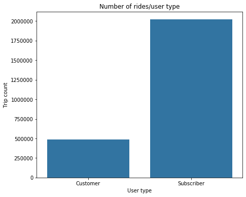

```python
# Plot user_type to get an idea of counts
plt.figure(figsize=[16, 6]);
base_color = sb.color_palette()[0]

plt.subplot(1, 2, 2);
sb.countplot(data=fordtrips, x = 'user_type', color=base_color,)
plt.xlabel('User type')
plt.ylabel('Trip count');
plt.title('Number of rides/user type');
```

> As I expected, it looks like there are way more trips for subscribers(close to 2M) than customers(close to 1/2M). Subscribers tend to be daily riders so their trip usage is showing way more than casual rider.

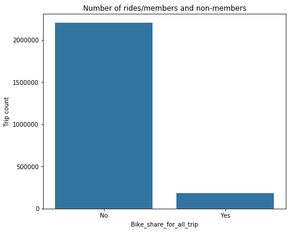

```python
# Plot bike_share_for_all_trip --which tracks members who are enrolled in the Bike Share for All program for low-income residents.
plt.figure(figsize=[16, 6]);
base_color = sb.color_palette()[0]
plt.subplot(1, 2, 2);
sb.countplot(data=fordtrips, x = 'bike_share_for_all_trip', color=base_color)
plt.xlabel('Bike_share_for_all_trip')
plt.ylabel('Trip count');
plt.title('Number of rides/members and non-members');
```

> Riders who are members of 'Bike share for all' program are way less as compare to riders who are not.

### Let's try to see in terms of duration, where does most of the trip data falls.

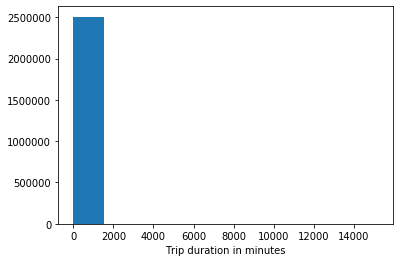

```python
# Overall minutes for all trips together
plt.hist(data=fordtrips, x='duration_minute',color=base_color)
plt.xlabel('Trip duration in minutes');
```

> Looking at the duration_minute lot, we can see that the distribution is heavily scewed to the right, reinforcing the idea that the bikes are generally used for short trips. There might be some outliers in the data. Let's plot a boxplot to get a clear picture regarding outliers.

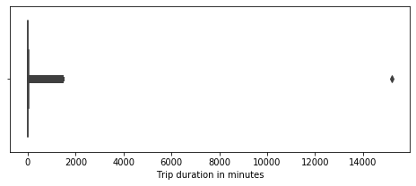

```python
# Plot a boxplot to see if there are any outliers
plt.figure(figsize=(8,3))
sb.boxplot(x='duration_minute', data=fordtrips,  orient='h')
plt.xlabel('Trip duration in minutes');
```

> Above shows outliers for duration_minute. Let's use percentiles and see where the higher values fall so that we can filter out the outliers.

```python
# Get the info on duration_minute to check 99% data to find out where most of the data falls
fordtrips['duration_minute'].describe(percentiles=[0.99])
```

```
count    2.506983e+06
mean     1.346081e+01
std      3.291190e+01
min      1.000000e+00
50%      9.516667e+00
99%      6.876667e+01
max      1.520183e+04
Name: duration_minute, dtype: float64
```

> 99% of the data falls below 69 minutes. I am going to use that as a threshold to plot and see duration spread of bike usage. I am going to use the bins starting from 5-69 with 5 as an interval.

### Distribution of Ride Duration

> The bike share system offers a short-term mode of transport, and this is reflected in its pricing structure. 30-minute and 45-minute time limits are imposed on the customers and subscribers, respectively, with a $3 fee for every additional 15 minutes. To avoid surcharges, I hypothesize that most rentals are below the prescribed limit.

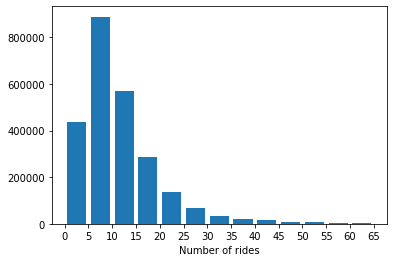

```python
# Use the 99% value for duration_minute from above info to create bin and exclude the outlier
bin_edges = np.arange(0, 69, 5)
ticks = np.arange(0, 69, 5)
plt.hist(data=fordtrips, x='duration_minute', bins = bin_edges, rwidth = 0.8, color=base_color)
plt.xticks(ticks, ticks)
plt.xlabel('Trip duration in minutes');
plt.xlabel('Number of rides');
```

> Let's remove the outliers.

```python
# filter out outlier trip records where the duration was very long
fordtrips = fordtrips.query('duration_minute <= 69')
```

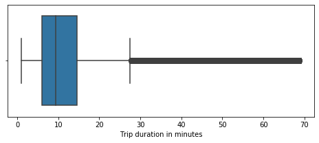

```python
# Plot a boxplot again
plt.figure(figsize=(8,3))
sb.boxplot(x='duration_minute', data=fordtrips,  orient='h', color=base_color)
plt.xlabel('Trip duration in minutes');
```

> Most number of the trips fall around 5-15 minutes.

### Let's try to get a sense of overall number of trips at month, day of the week and an hours of the week level.

### Which months have higher number of bike share rides?

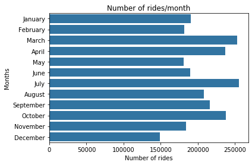

```python
# Plot overall bike share ride count for all the months of 2019
base_color = sb.color_palette()[0]
sb.countplot(data=fordtrips, y = 'start_month', color=base_color)
plt.xlabel('Number of rides');
plt.ylabel('Months');
plt.title('Number of rides/month');
```

> Looking at the above plot it looks like there are two peaks when it comes to hugher number of ride usage. Month of March & April shows higher usage of rides and also summer months July-Oct.

### What days of the week do we see higher number of bike share rides?

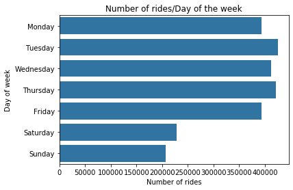

```python
# Plotting the start_dayofweek
base_color = sb.color_palette()[0]
sb.countplot(data=fordtrips, y = 'start_dayofweek', color=base_color)
plt.xlabel('Number of rides')
plt.ylabel('Day of week');
plt.title('Number of rides/Day of the week');
```

> When we plot the counts for each day of the week, it can be easily seen that weekend trips are lower as expected. For the weekdays, Tuesday, Wednesday and Thursday seems to have higher number of bike rides.

### What hour of the day the ride usage is high? Does it correspond with peak rush hour?

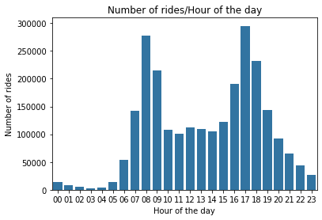

```python
# Plot overall count of the rides over all the hours of the day
base_color = sb.color_palette()[0]
sb.countplot(data=fordtrips, x = 'start_hourofday', color=base_color)
plt.xlabel('Hour of the day')
plt.ylabel('Number of rides');
plt.title('Number of rides/Hour of the day');
```

> Looking at the above plot, rush hours tend to have higher number of bike share rides as expected. The peaks at 8 AM and 5 PM confirms my gut instinct that the bike share system is busiest during commute hours. Along the same lines, it should not come as a surprise that the quietest times are in the wee hours of the night.

### Do the daily ford ride usage differ a lot over 12 months?

```python
#Count of daily bike rides from July 2019 to December 2019
def transform_axis(dailyBike, pos):
    if dailyBike >= 1000:
        value = int(dailyBike/1000)
        return '{:d}K'.format(value)
    elif dailyBike >= 1000000:
        value = int(dailyBike/1000000)
        return '{:d}M'.format(value)
    else:
        return int(dailyBike)
```

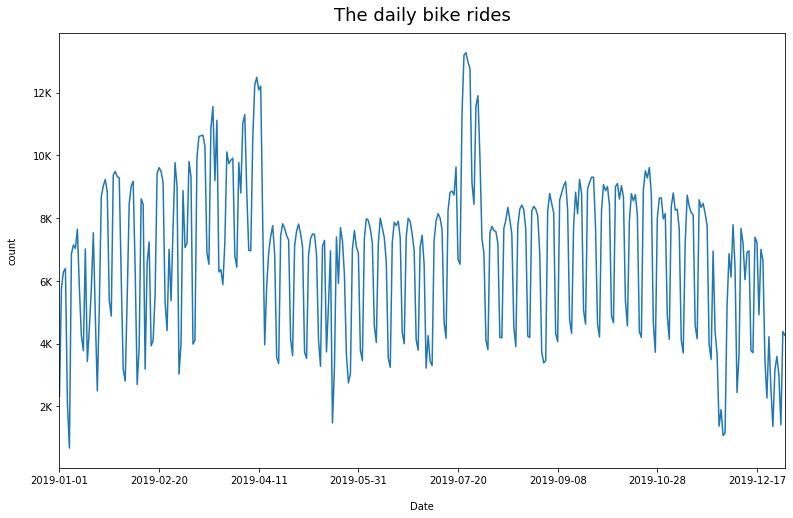

```python
fordtrips.groupby('start_date').agg({'bike_id':'count'}).plot(style='-', legend=False, figsize=(13,8),color=base_color)
plt.title('The daily bike rides', fontsize=18, y=1.015)
plt.xlabel('Date', labelpad=16)
plt.ylabel('count', labelpad=16)
axis = plt.gca()
axis.yaxis.set_major_formatter(tick.FuncFormatter(transform_axis))
```

> If you look at the plot for all months in 2019, the number of daily bike rides shows higher March and July. July is a summer month so it is understandable that the number of rides are high. Overall daily ride usage doesn't differ a lot except few peaks.

## Bivariate Exploration

### Is the monthly trip usage for both users shows similar trend?

> I am going to use groupby to aggregate the data for the user types Customers & Subscribers

```python
# Number of rides per month for customers and subscribers
user_rides = fordtrips.groupby(['start_month','user_type']).size().reset_index()
```

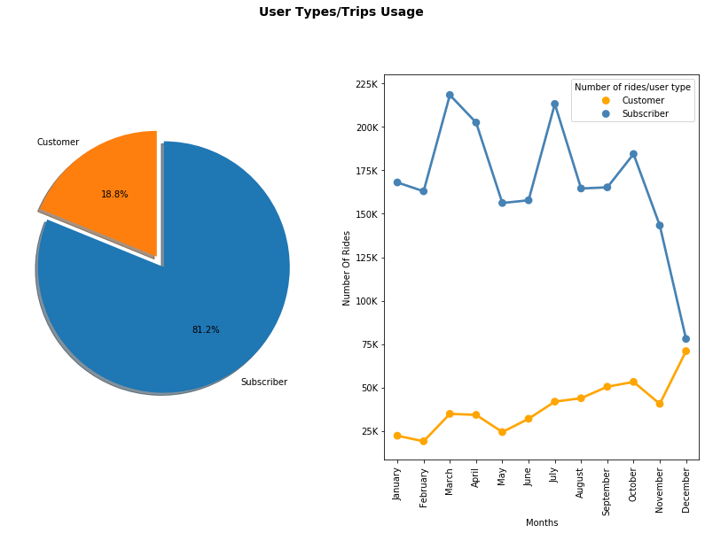

```python
plt.figure(figsize=[14, 8]);

# Plot user_type and yearly trip usage
plt.subplot(1, 2, 1);
sorted_vals = fordtrips.user_type.value_counts()/fordtrips.shape[0];
plt.pie(sorted_vals, explode=[0, 0.1], labels=sorted_vals.index, startangle=90, counterclock=False, autopct='%1.1f%%', shadow=True);
#plt.axis('square');
#plt.title('User Types/Yearly Trip Usage', fontsize=14, fontweight='semibold', y=1.015);

# Plot user_type and monthly trip usage
plt.subplot(1, 2, 2);
palette={'Subscriber':'steelblue', 'Customer':'Orange'};
ax = sb.pointplot(data=user_rides, x='start_month', y=0, hue='user_type', palette=palette);
ax.legend(title='Number of rides/user type');
axis = plt.gca();
axis.yaxis.set_major_formatter(tick.FuncFormatter(transform_axis));
plt.xticks(rotation=90);
plt.xlabel('Months');
plt.ylabel('Number Of Rides');

plt.suptitle('User Types/Trips Usage', fontsize=14, fontweight='semibold', y=1.015);
```

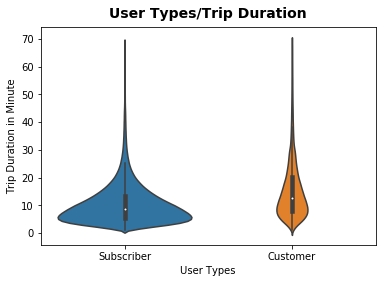

```python
# Plot user_type and duration_minute
sb.violinplot(data=fordtrips, x='user_type', y='duration_minute', order=["Subscriber", "Customer"], scale='count');
plt.xlabel('User Types');
plt.ylabel('Trip Duration in Minute');
plt.title('User Types/Trip Duration', fontsize=14, fontweight='semibold', y=1.015);
```

> As we know, there are more subscribers than customers and we can see it when we plot the overall trip usage. Acroos the months, customer's trip usage shows gradual increase with a little dip in November and May and then hiving highest usage in December considering people being on holiday break. Subscribers on the other hand shows peaks in March and July with still holding high usage and dropping the usage drastically after October considering the opposite effect of holidays.  
> When we look at the violin plots for both the subscribers and customers, the distribution shows more data points for the duration 0-20 minutes for both. Subscriber's highest data points value seems to be little less than customers, considering casual users being casual might ride the bike for longer time. Subscribers might be using the bike for fix and short distance as they ride the bike almost daily.

### Do members and non-members of the 'Bike share for all' program behave similar when it comes to monthly ride usage and ride duration?

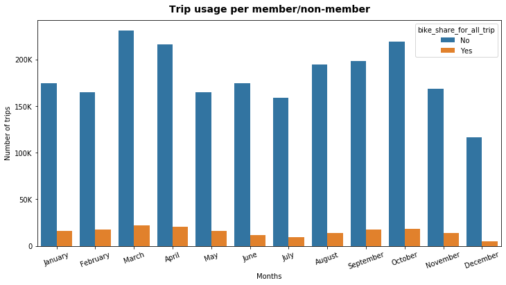

```python
# duration_minute and ride_share_for_all
plt.figure(figsize=(12,6))
sb.countplot(data=fordtrips, x='start_month', hue='bike_share_for_all_trip')
plt.title('Trip usage per member/non-member', fontsize=14, fontweight='semibold', y=1.015)
plt.xlabel('Months')
plt.ylabel('Number of trips')
axis = plt.gca()
axis.yaxis.set_major_formatter(tick.FuncFormatter(transform_axis))
plt.xticks(rotation=20);
```

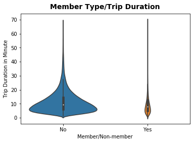

```python
# Plot membertype and duration_minute
sb.violinplot(data=fordtrips, x='bike_share_for_all_trip', y='duration_minute', scale='count');
plt.xlabel('Member/Non-member');
plt.ylabel('Trip Duration in Minute');
plt.title('Member Type/Trip Duration', fontsize=14, fontweight='semibold', y=1.015);
```

> Members and non-members of the 'Bike share for all' program seem to have a similar distribution of trip duration, mostly falling between 0-20 minutes. There is definitely similar pattern when it comes to their trip usage over 12 months of 2019. Both members and non-members shows higher usage in March and October. Surprisingly, summer months doesn't show the highest usage in both members and non members. Winter months shows decline in usage as expected.

## Multivariate Exploration

### Comaparing average trip duration/customers and subscribers/days of the week and hour of the day

I am using two categorical variables, Day of the week and user type and mean duration as third variable. I am using pointplot, which shows only the mean (or other estimator) value.

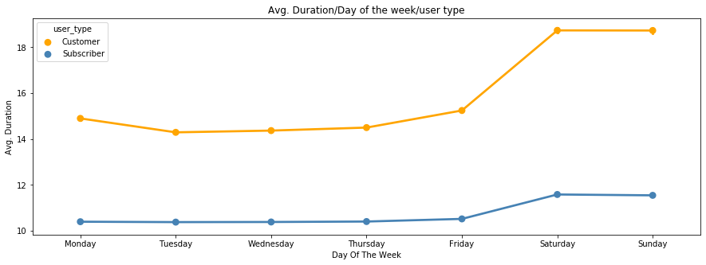

```python
# Plot number of rides per user type for each day of the week
plt.figure(figsize=(15,5))
sb.pointplot(data=fordtrips, x='start_dayofweek', y='duration_minute', hue='user_type', palette=palette)
plt.title('Avg. Duration/Day of the week/user type')
plt.xlabel('Day Of The Week')
plt.ylabel('Avg. Duration')
```

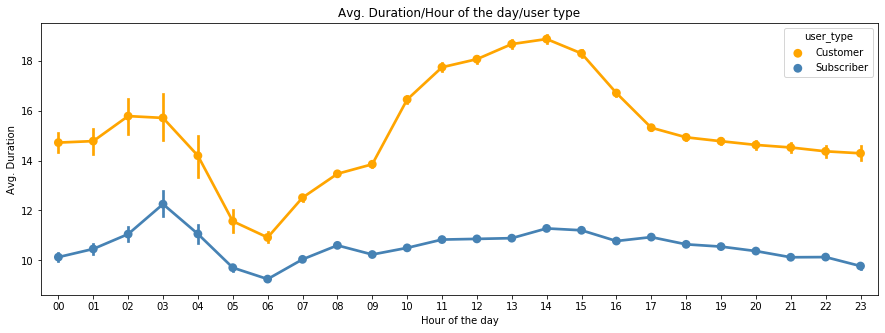

```python
# Plot number of rides per user type for each month
plt.figure(figsize=(15,5))
sb.pointplot(data=fordtrips, x='start_hourofday', y='duration_minute', hue='user_type', palette=palette)
plt.title('Avg. Duration/Hour of the day/user type')
plt.xlabel('Hour of the day')
plt.ylabel('Avg. Duration');
```

### Ride usage across day of the week and hours of the day for customers and subscribers

> I want to explore how the usage is distributed over the hours of the day for customers and subscribers. For this, I am grouping the number of rides for each day of the week and each hour of the day. Then plotting the heatmap using three variables start_dayofweek, start_hourofday and user_type

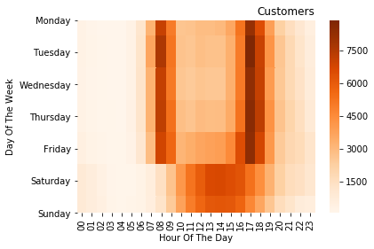

```python
# Creating a heatmap for the relationship between  hour of the week and start_dayofweek for each user type such as customer and subscriber

# create a dataframe for all the trips for user Customer
customers = fordtrips.query('user_type=="Customer"')

ct_counts = customers.groupby(['start_dayofweek', 'start_hourofday']).size()
ct_counts = ct_counts.reset_index(name='count')
ct_counts = ct_counts.pivot(index = 'start_dayofweek', columns = 'start_hourofday', values = 'count')

#plot the heatmap
#plt.subplot(2, 1, 2)
sb.heatmap(ct_counts, cmap='Oranges');
plt.xlabel('Hour Of The Day');
plt.ylabel('Day Of The Week');
plt.title('Customers', loc='right');
```

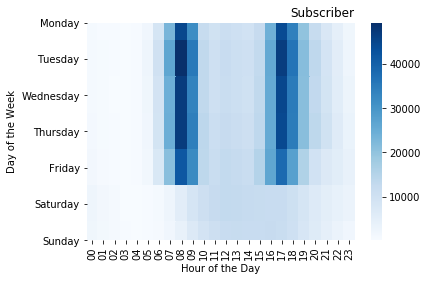

```python
# Creating a heatmap for the rel;ationship between  hour of the week and start_dayofweek for each user type such as customer and subscriber

# create a dataframe for all the trips for user Subscribers
subscribers = fordtrips.query('user_type == "Subscriber"')

st_counts = subscribers.groupby(['start_dayofweek', 'start_hourofday']).size()
st_counts = st_counts.reset_index(name='count')
st_counts = st_counts.pivot(index='start_dayofweek', columns='start_hourofday', values='count')

#plot the heatmap
#plt.subplot(2, 1, 2)
sb.heatmap(st_counts, cmap='Blues');
plt.title('Subscriber', loc='right');
plt.xlabel('Hour of the Day');
plt.ylabel('Day of the Week');
```

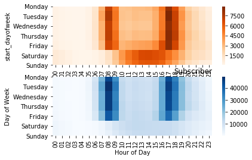

```python
# Creating a heatmap for the rel;ationship between  hour of the week and start_dayofweek for each user type such as customer and subscriber
plt.suptitle('Hourly Usage during Weekdays for Customers and Subscribers');
# create a dataframe for all the trips for user Customer
customers = fordtrips.query('user_type=="Customer"');
ct_counts = customers.groupby(['start_dayofweek', 'start_hourofday']).size();
ct_counts = ct_counts.reset_index(name='count');
ct_counts = ct_counts.pivot(index = 'start_dayofweek', columns = 'start_hourofday', values = 'count');


# create a dataframe for all the trips for user Subscribers
subscribers = fordtrips.query('user_type == "Subscriber"');
st_counts = subscribers.groupby(['start_dayofweek', 'start_hourofday']).size();
st_counts = st_counts.reset_index(name='count');
st_counts = st_counts.pivot(index='start_dayofweek', columns='start_hourofday', values='count');


fig = plt.figure();
ax1 = fig.add_subplot(211);
ax2 = fig.add_subplot(212);

# We use ax parameter to tell seaborn which subplot to use for this plot

sb.heatmap(ct_counts, cmap='Oranges',ax=ax1);
plt.title('Customer', loc='right');
plt.xlabel('Hour of Day');
plt.ylabel('Day of Week');

sb.heatmap(st_counts, cmap='Blues',ax=ax2);
plt.title('Subscriber', loc='right');
plt.xlabel('Hour of Day');
plt.ylabel('Day of Week');
```

> Heatmap is a great way to show the relation between day of the week and hour of the day to measure the ride usage. Subscribers clearly have heavy usage during the weekdays rush hours (Monday - Friday, 7am-9am and 4pm-6pm. Considering these users have subscription and might be using the bike rides for more routine/fix ddistances for example to go to work. Early, middle of the day and late hours as well as weekends have very low usage. On the other hand, customers seems to have good amount of usage on the weekends during daytime hours 9am -8pm as they must be using it for casual bike riding. Eary and late hours of the day seems to have low usage as expected.

# Resources

> https://www.programiz.com/python-programming/datetime/strftime https://pbpython.com/pandas_dtypes_cat.html -- ordered category data type https://github.com/DavidMStraub/flavio-tutorial/issues/1 -- MacTex issue fix https://seaborn.pydata.org/generated/seaborn.countplot.html -- seaborn plots https://matplotlib.org/3.1.3/api/_as_gen/matplotlib.pyplot.plot.html https://matplotlib.org/gallery/images_contours_and_fields/image_annotated_heatmap.html#sphx-glr-gallery-images-contours-and-fields-image-annotated-heatmap-py https://stackoverflow.com/questions/56350531/seaborn-violinplot-experiences-difficulty-with-too-many-variables -- boxplot fixes https://seaborn.pydata.org/generated/seaborn.pointplot.html -- pointplot https://stackoverflow.com/questions/48272437/combining-two-heat-maps-in-seaborn https://stackoverflow.com/questions/51129404/python-how-to-plot-multiple-seaborn-heatmaps-side-by-side/51129428 -- plotting two heatmaps